# Couse Project 1

2022-08-05

## Loading and preprocessing data

Including dplyr and ggplot2 packages

```r
data <- read.csv('activity.csv')

library(dplyr)
```

```r
library(ggplot2)
```

##What is mean total number of steps taken per day?

1. Calculate the total number of steps taken per day

```r
workdata <- data

##Grouping data by days
workdata1 <- data %>%
  group_by(date) %>%
  summarise(total_steps = sum(steps))
```

2. Make a histogram of the total number of steps taken each day

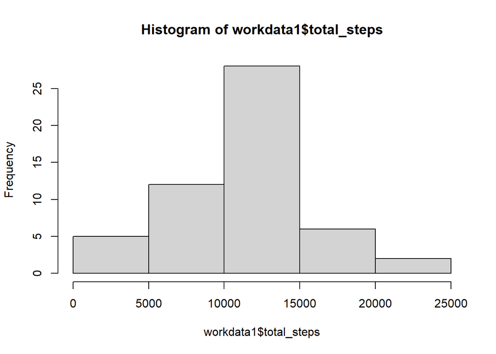

```r
hist(workdata1$total_steps)
```

3. Calculate and report the mean and median of the total number of steps taken per day

```r
mean(workdata1$total_steps, na.rm = TRUE)
```

```
## [1] 10766.19
```

```r
median(workdata1$total_steps, na.rm = TRUE)
```

```
## [1] 10765
```

##What is the average daily activity pattern?

1. Make a time series plot (i.e. type = “l”) of the 5-minute interval (x-axis) and the average number of steps taken, averaged across all days (y-axis)

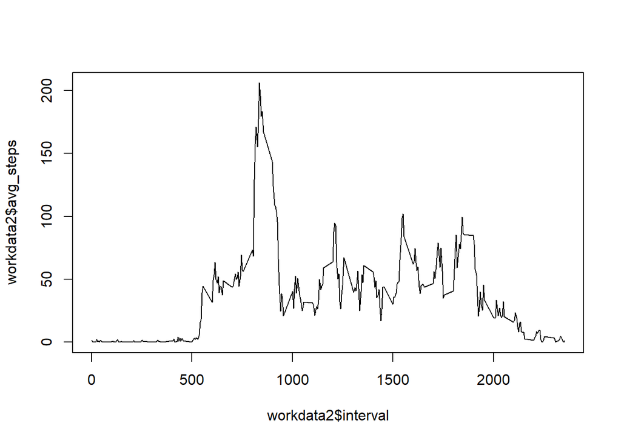

```r
##group data by intervals
workdata2 <- data %>%
  group_by(interval) %>%
  summarise(avg_steps = mean(steps, na.rm = TRUE))

##plotting
plot(workdata2$interval, workdata2$avg_steps, type = "l")
```

Which 5-minute interval, on average across all the days in the dataset, contains the maximum number of steps?

```r
workdata2$interval[which.max(workdata2$avg_steps)]
```

```
## [1] 835
```

## Imputing missing values

1. Calculate and report the total number of missing values in the dataset

```r
NA_num <- max(length(data$steps[is.na(data$steps)]), length(data$date[is.na(data$steps)]),
              length(data$date[is.na(data$steps)]))
NA_num
```

```
## [1] 2304
```

2. Devise a strategy for filling in all of the missing values in the dataset: fill the missing data with average values
3. Create a new dataset that is equal to the original dataset but with the missing data filled in.

```r
workdata3 <- data
workdata3$steps[is.na(workdata3$steps)] <- mean(workdata3$steps, na.rm = TRUE)
```

4. Make a histogram of the total number of steps taken each day and Calculate and report the mean and median total number of steps taken per day.

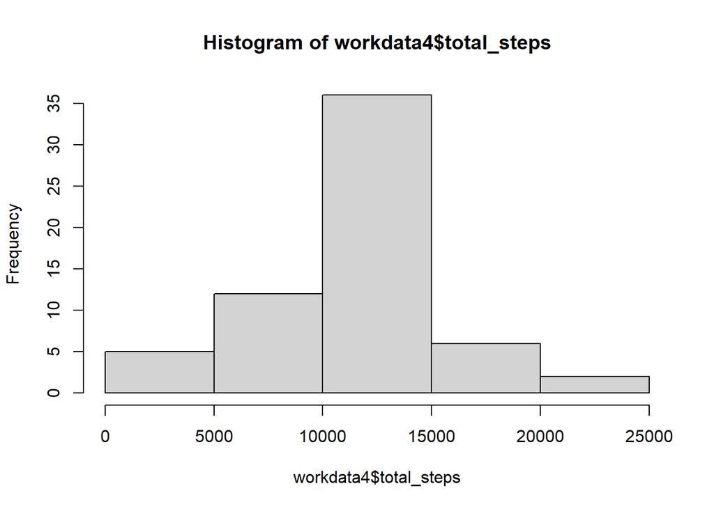

```r
##similar to the first part
workdata4 <- workdata3 %>%
  group_by(date) %>%
  summarise(total_steps = sum(steps),
            ##mean_steps = mean(steps, na.omit = TRUE), ##misunderstood the question
            ##med_steps = median(steps)
            )

##plotting histogram
hist(workdata4$total_steps)
```

```r
##mean and median
mean(workdata4$total_steps, na.rm = TRUE)
```

```
## [1] 10766.19
```

```r
median(workdata4$total_steps, na.rm = TRUE)
```

```
## [1] 10766.19
```

It looks like median is higher than in the set with n/a data. Mean, as could be expected for such strategy, practically unchanged.

##Are there differences in activity patterns between weekdays and weekends?

1. Create a new factor variable in the dataset with two levels – “weekday” and “weekend” indicating whether a given date is a weekday or weekend day.

```r
day <- ifelse(weekdays(as.Date(data$date), abbreviate = TRUE) %in% c("Вс", "Сб"), "weekend", "weekday")

##create new dataset for the next task
workdata5 <- cbind(workdata3, day)
```

2. Make a panel plot containing a time series plot (i.e. type = “l”) of the 5-minute interval (x-axis) and the average number of steps taken, averaged across all weekday days or weekend days (y-axis).

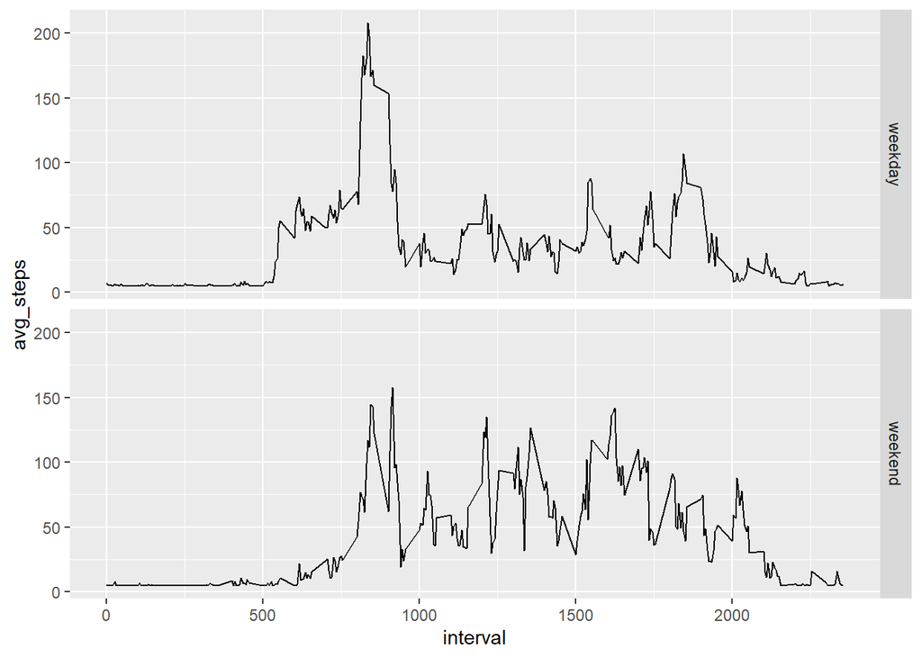

```r
##preparing the data by grouping by interval and day
workdata5 <- workdata5 %>%
  group_by(interval, day) %>%
  summarise(avg_steps = mean(steps, na.rm = TRUE), .groups = "rowwise")

##plotting
qplot(interval, avg_steps, data = workdata5, geom = "line", facets = day~.)
```